# **How Can the Hospital Manage Admission Delays for Emergency Patients?**

Analysis of Admission Delays for Emergency Ward Patients

John Karuitha

Sunday September 24, 2023

```r
knitr::opts_chunk$set(echo = TRUE, message = FALSE, warning = FALSE)

if (!require(pacman)) {
  install.packages("pacman")
}
```

```r
pacman::p_load(
  tidyverse, janitor, skimr,
  kableExtra, readxl, conflicted,
  GGally, corrplot, ggthemes,
  randomForest, vip, stargazer,
  naivebayes, e1071, caret,
  kernlab, tidymodels
)

options(digits = 3)
theme_set(ggthemes::theme_clean())
```

# 1 **Summary**

In this analysis, I have used emergency department data from a fictitious hospital to generate insights to reduce waiting times. Following my analysis, I come up with the following insights.

My recommendations are as follows;

# 2 **Background**

In hospital emergency wards, the longer the patient waits in a queue before being attended, the greater the risk of mortality. In this analysis, I use data regarding the patient wait times in an emergency department in an anonymous hospital to derive insights that can help the hospital management reduce the wait times. Specifically, the analysis aims uncovering factors associated with admission delays so as to advise the management of actionable strategies to reduce the delays.

To achieve this goal, I run the following models for the analysis.

- Simple Linear Regression Model.
- Support Vector Machines (SVM) Model.
- Naive Bayes Model.
- Random Forest Model.

But first, I load and explore the data, run the models, and, finally, make recommendations. The analysis then concludes.

# 3 **Data**

## 3.1 *Overview of the Data*

In this section, I load and explore the data.

```r
## Load the data ----
waiting <- readxl::read_xlsx("Hw_data.xlsx") |>
  janitor::clean_names()

## Overview of the data
glimpse(waiting)
```

```
## Rows: 744
## Columns: 8
## $ date_and_time                        <dttm> 2016-05-01 00:00:00, 2016-05-01 …
## $ number_of_ed_beds                    <dbl> 72, 72, 72, 72, 72, 72, 72, 72, 7…
## $ number_of_ip_beds                    <dbl> 532, 532, 532, 532, 532, 532, 532…
## $ number_of_ed_pts                     <dbl> 57, 57, 52, 40, 40, 34, 26, 28, 2…
## $ number_of_ed_pts_waiting_ip_bed      <dbl> 9, 8, 9, 9, 9, 9, 11, 10, 12, 11,…
## $ number_of_critical_care_pts_display  <dbl> 3.5, 5.5, 5.5, 5.5, 6.5, 5.5, 6.0…
## $ door_to_bed_time_for_last_ed_patient <dbl> 1.82, 1.05, 1.10, 1.56, 0.01, 0.1…
## $ longest_admit_time_waiting_in_ed     <dbl> 3.55, 4.25, 6.91, 1.49, 2.11, 3.3…
```

The data consists of 744 observations of 8 variables. Table 1 below describes the variables.

```r
# Describing the variables in the raw data ----
tribble(
  ~Variable, ~Description,
  "date_and_time",
  "Time and date of patient arrival.",
  "number_of_ed_beds",
  "Number of beds in the emergency department.",
  "number_of_ip_beds",
  "Number of inpatient beds.",
  "number_of_ed_pts",
  "Number of emergency department patients.",
  "number_of_ed_pts_waiting_ip_bed",
  "Number of emergency department patients waiting for bed",
  "number_of_critical_care_pts_display",
  "Number of critical care patients display",
  "door_to_bed_time_for_last_ed_patient",
  "Door to bed time for last patient in emergency department.",
  "longest_admit_time_waiting_in_ed",
  "Longest admission time for patient waiting in emergency department."
) |>
  kbl(booktabs = TRUE, caption = "Variables Description") |>
  kable_classic(
    full_width = TRUE,
    latex_options = "hold_position"
  )
```

Variables Description

| Variable | Description |
| --- | --- |
| date_and_time | Time and date of patient arrival. |
| number_of_ed_beds | Number of beds in the emergency department. |
| number_of_ip_beds | Number of inpatient beds. |
| number_of_ed_pts | Number of emergency department patients. |
| number_of_ed_pts_waiting_ip_bed | Number of emergency department patients waiting for bed |
| number_of_critical_care_pts_display | Number of critical care patients display |
| door_to_bed_time_for_last_ed_patient | Door to bed time for last patient in emergency department. |
| longest_admit_time_waiting_in_ed | Longest admission time for patient waiting in emergency department. |

The target variable (dependent variable) is the longest admit time waiting in emergency department (longest_admit_time_waiting_in_ed).

## 3.2 *Missing and Duplicate values*

The data has no missing values.

```r
## Check missing values
waiting |>
  sapply(is.na) |>
  colSums() |>
  tibble(variables = names(waiting), missing = _) |>
  kbl(booktabs = TRUE, caption = "Missing values") |>
  kable_classic(
    full_width = FALSE,
    latex_options = "hold_position"
  )
```

Missing values

| variables | missing |
| --- | --- |
| date_and_time | 0 |
| number_of_ed_beds | 0 |
| number_of_ip_beds | 0 |
| number_of_ed_pts | 0 |
| number_of_ed_pts_waiting_ip_bed | 0 |
| number_of_critical_care_pts_display | 0 |
| door_to_bed_time_for_last_ed_patient | 0 |
| longest_admit_time_waiting_in_ed | 0 |

Likewise, the data has no duplicate rows.

```r
## Check duplicate observations
waiting |>
  janitor::get_dupes()
```

```
## # A tibble: 0 × 9
## # ℹ 9 variables: date_and_time <dttm>, number_of_ed_beds <dbl>,
## #   number_of_ip_beds <dbl>, number_of_ed_pts <dbl>,
## #   number_of_ed_pts_waiting_ip_bed <dbl>,
## #   number_of_critical_care_pts_display <dbl>,
## #   door_to_bed_time_for_last_ed_patient <dbl>,
## #   longest_admit_time_waiting_in_ed <dbl>, dupe_count <int>
```

Given that this is a relatively clean dataset, I embark on data exploration.

## 3.3 *Exploratory Data Analysis*

I start by summarising the data.

```r
## Summary statistics for the data
waiting |>
  select(-date_and_time) |> skimr::skim_without_charts() |>
  select(-complete_rate, -n_missing) |>
  set_names(c(
    "no", "variable", "Mean", "SD", "Min",
    "Q1", "Median", "Q3", "Max"
  )) |>
  select(-no) |> kbl(booktabs = TRUE, caption = "Data Summary") |>
  kable_classic(
    full_width = FALSE, latex_options = "hold_position"
  )
```

Data Summary

| variable | Mean | SD | Min | Q1 | Median | Q3 | Max |
| --- | --- | --- | --- | --- | --- | --- | --- |
| number_of_ed_beds | 72.000 | 0.00 | 72.00 | 72.00 | 72.00 | 72.000 | 72.00 |
| number_of_ip_beds | 532.000 | 0.00 | 532.00 | 532.00 | 532.00 | 532.000 | 532.00 |
| number_of_ed_pts | 60.579 | 19.57 | 20.00 | 43.00 | 62.00 | 76.000 | 109.00 |
| number_of_ed_pts_waiting_ip_bed | 10.633 | 5.24 | 0.00 | 6.00 | 10.00 | 14.000 | 29.00 |
| number_of_critical_care_pts_display | 5.443 | 2.35 | 0.00 | 3.50 | 5.50 | 7.000 | 14.50 |
| door_to_bed_time_for_last_ed_patient | 0.761 | 1.16 | -0.07 | 0.03 | 0.23 | 0.883 | 6.76 |
| longest_admit_time_waiting_in_ed | 5.041 | 5.24 | 0.00 | 1.63 | 3.36 | 6.562 | 30.02 |

I do a pairs plot for the variables to uncover the significant relationships between the variables.

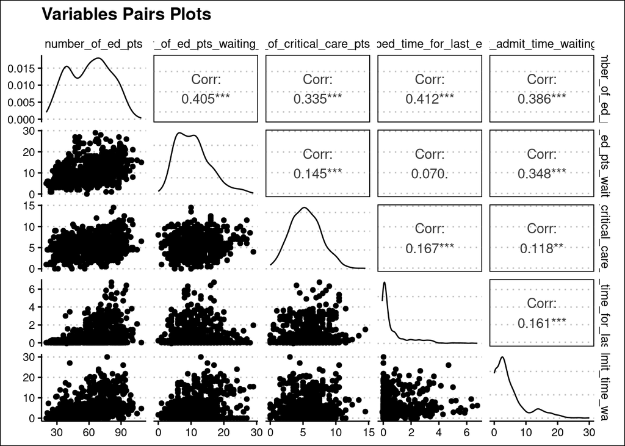

Pairs Plot for Raw Data

```r
## Pairs plotof the raw data
waiting |>
  select(
    -date_and_time, -number_of_ed_beds,
    -number_of_ip_beds
  ) |>
  GGally::ggpairs(title = "Variables Pairs Plots")
```

Note that the number of both inpatient and emergency department beds are constant and hence the NA value for the correlations of these variables and other variables in the dataset. Hence, I omit both variables in the correlation analysis.

Overall, there are significant correlations between waiting times and the number of patients (number_of_ed_pts), and the patients waiting in inpatient beds (number_of_ed_pts_waiting_ip_bed). The variables can be useful in explaining waiting times in emergency rooms except for the number of beds.

I remove the two constant columns from the data; number_of_ed_beds, number_of_ip_beds.

```r
## Remove the columns with constant values
## These are; number_of_ed_beds, number_of_ip_beds.
waiting <- waiting |>
  remove_constant()
```

## 3.4 *Feature Engineering*

Given that the flow of patients may vary by day of the week and time of day, I split the date_and_time variable into two variables, weekday (Sunday (1) to Saturday (7)) and hour of the day (in 24 hour format 00 to 23). Note that the data was collected in May 2016 hence the month and year may not be useful in the analysis.

Given that I also run Naive Bayes and Support Vector Machines (SVM) models, I create a new categorical variable from the wait times. Specifically, I segment the target variable (longest_admit_time_waiting_in_ed) into 9 categories. Examples of these categories are patients that wait for 0-3.34 minutes, 3.34 to 6.67 minutes, and so on. I have used my own judgement to select these segments.

```r
## Creating new variables, day of week, hour of day, and wait_cat
## wait_cat bins the waiting times into 9 categories
waiting <- waiting |>
  mutate(
    week_day = wday(date_and_time, label = FALSE),
    hour_day = hour(date_and_time)
  ) |>
  select(-date_and_time) |>
  mutate(
    hour_day = factor(hour_day),
    week_day = factor(week_day)
  ) |>
  mutate(wait_cat = cut(longest_admit_time_waiting_in_ed,
    breaks = 9
  ))
```

# 4 **Analysis**

## 4.1 Distribution of Wait Times

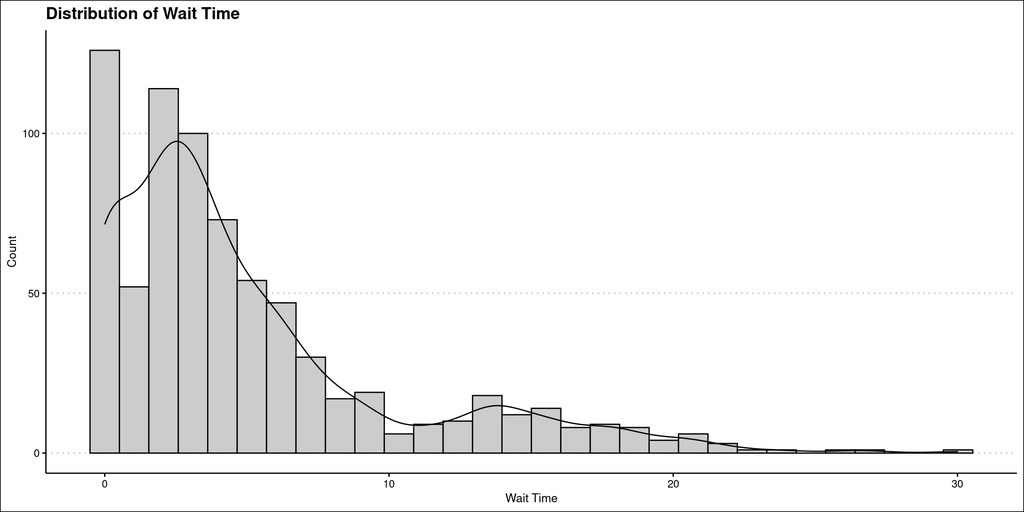

Distribution of Patient Wait Times

```r
## Distribution of patient wait times
waiting |> ggplot(aes(x = longest_admit_time_waiting_in_ed)) +
  geom_histogram(color = "black", fill = "gray80") +
  geom_density(aes(y = ..count..)) +
  labs(x = "Wait Time", y = "Count",
    title = "Distribution of Wait Time")
```

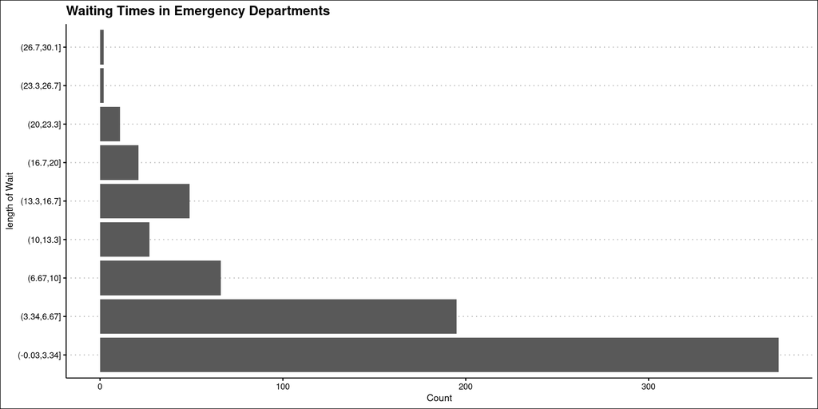

Waiting Times in Emergency Departments

```r
## Waiting time by categories
waiting |> count(wait_cat) |>
  ggplot(mapping = aes(x = wait_cat, y = n)) + geom_col() +
  labs(x = "length of Wait", y = "Count",
  title = "Waiting Times in Emergency Departments") + coord_flip()
```

Again the skewness in the histogram repeats, with most waits between zeo and 4 minutes. However, there are outliers of upto thirty minutes which are a cause for concern.

## 4.2 **Day of Week and Hour of Day with Most emergencies**

Table 4 below shows the distribution of cases by week day. The table shows that most cases occur on Sundays, Mondays, and Tuesdays with 120 admissions each.

```r
## Patients by day of the week
waiting |>
  count(week_day) |>
  kbl(booktabs = TRUE, caption = "Patients by Day of Week") |>
  kable_classic(
    full_width = FALSE,
    latex_options = "hold_position"
  )
```

Patients by Day of Week

| week_day | n |
| --- | --- |
| 1 | 120 |
| 2 | 120 |
| 3 | 120 |
| 4 | 96 |
| 5 | 96 |
| 6 | 96 |
| 7 | 96 |

For hour of day, there are a uniform number of admissions for this data (Table 5).

```r
## Patients by hour of day
waiting |>
  count(hour_day) |>
  kbl(booktabs = TRUE, caption = "Patients by Hour of Day") |>
  kable_classic(
    full_width = FALSE,
    latex_options = "hold_position"
  )
```

Patients by Hour of Day

| hour_day | n |
| --- | --- |
| 0 | 31 |
| 1 | 31 |
| 2 | 31 |
| 3 | 31 |
| 4 | 31 |
| 5 | 31 |
| 6 | 31 |
| 7 | 31 |
| 8 | 31 |
| 9 | 31 |
| 10 | 31 |
| 11 | 31 |
| 12 | 31 |
| 13 | 31 |
| 14 | 31 |
| 15 | 31 |
| 16 | 31 |
| 17 | 31 |
| 18 | 31 |
| 19 | 31 |
| 20 | 31 |
| 21 | 31 |
| 22 | 31 |
| 23 | 31 |

## 4.3 **Models**

In this section, I run the models in the following order.

1. Linear Regression Model.
2. Support Vector Machines Model.
3. Naive Bayes Model.
4. Random forest Model.

### 4.3.1 *Linear Regression Model.*

```r
## Run the regression model
lm_model <- lm(longest_admit_time_waiting_in_ed ~ . - wait_cat, data = waiting)
```

```r
## Generate regression model output for either HTML or PDF output

if (knitr::is_html_output()) {

  stargazer::stargazer(lm_model,
  type = "html",
  title = "Regression Output"
)
} else {

  stargazer::stargazer(lm_model,
  type = "latex",
  title = "Regression Output",
  font.size = "tiny"
)
}
```

**Regression Output**

|  | *Dependent variable:* |
| --- | --- |
|  | longest_admit_time_waiting_in_ed |
| number_of_ed_pts | 0.026 |
|  | (0.020) |
| number_of_ed_pts_waiting_ip_bed | 0.109** |
|  | (0.043) |
| number_of_critical_care_pts_display | -0.030 |
|  | (0.075) |
| door_to_bed_time_for_last_ed_patient | 0.207 |
|  | (0.156) |
| week_day2 | -0.451 |
|  | (0.588) |
| week_day3 | 0.896 |
|  | (0.632) |
| week_day4 | 0.493 |
|  | (0.619) |
| week_day5 | 2.140*** |
|  | (0.641) |
| week_day6 | 0.812 |
|  | (0.626) |
| week_day7 | -0.448 |
|  | (0.606) |
| hour_day1 | -0.377 |
|  | (1.120) |
| hour_day2 | -0.010 |
|  | (1.140) |
| hour_day3 | -0.421 |
|  | (1.170) |
| hour_day4 | -0.593 |
|  | (1.200) |
| hour_day5 | -0.037 |
|  | (1.220) |
| hour_day6 | -0.249 |
|  | (1.230) |
| hour_day7 | -0.503 |
|  | (1.230) |
| hour_day8 | 0.647 |
|  | (1.190) |
| hour_day9 | -0.642 |
|  | (1.140) |
| hour_day10 | 1.550 |
|  | (1.130) |
| hour_day11 | 3.750*** |
|  | (1.120) |
| hour_day12 | 4.740*** |
|  | (1.130) |
| hour_day13 | 5.110*** |
|  | (1.130) |
| hour_day14 | 6.430*** |
|  | (1.140) |
| hour_day15 | 4.820*** |
|  | (1.140) |
| hour_day16 | 4.990*** |
|  | (1.150) |
| hour_day17 | 3.640*** |
|  | (1.150) |
| hour_day18 | 2.900** |
|  | (1.150) |
| hour_day19 | 0.473 |
|  | (1.170) |
| hour_day20 | 1.580 |
|  | (1.170) |
| hour_day21 | -0.220 |
|  | (1.170) |
| hour_day22 | -0.201 |
|  | (1.140) |
| hour_day23 | -0.116 |
|  | (1.120) |
| Constant | 0.326 |
|  | (1.300) |
| Observations | 744 |
| R<sup>2</sup> | 0.339 |
| Adjusted R<sup>2</sup> | 0.308 |
| Residual Std. Error | 4.360 (df = 710) |
| F Statistic | 11.000*** (df = 33; 710) |
| *Note:* | p<0.1; p<0.05; p<0.01 |

The critical factors include;

- Number_of_ed_patients_waiting_in_ip_beds.
- Weekday.
- Hour of day.

Specifically, the number of patients waiting in inpatient beds has a direct relationship with waiting times. Besides, some days of the week are likely to experience longer waiting times than others. For instance, compared to Sunday (day 1), Thursday(day 5) has longer waiting times. Likewise, some hours of the day see longer waiting times. As case in point, 1100 hrs has a higher waiting times compared to midnight.

Recommendation: Increase the number of staff during peak days like Thursday so as to clear the number of patients waiting in inpatient beds.

### 4.3.2 *Support Vector Machines Model.*

```r
## Create a dataset for Naive Bayes and SVM Models

final_data <- waiting |>
  select(-longest_admit_time_waiting_in_ed) |>
  data.frame()
```

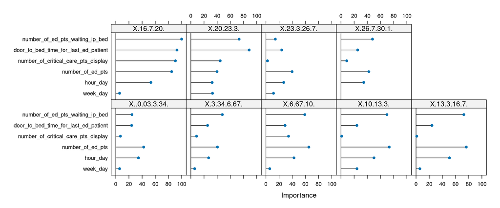

```r
# Create cross validation folds
train_control <- trainControl(
  method = "repeatedcv", number = 10, repeats = 3)
# Fit the model
svm_model <- train(wait_cat ~ ., data = final_data,
  method = "svmLinear", trControl = train_control,
  preProcess = c("center", "scale"), tuneGrid = expand.grid(C = seq(0, 2,
    length = 20
  )))
# View the model
plot(varImp(svm_model))
```

### 4.3.3 *Naive Bayes Model.*

To run Naive Bayes model, I have divided the outcome variable into categories to create a categorical variable (wait_cat). The variable has nine categories. For instance, how many times did admissions delay for between zero and three minutes, and so on. This is the `wait_cat` variable (see section 3.4 on feature engineering).

Recommendation: The implication is that in days and hours where there is projected to be more patients, we should have additional staff and portable emergency wards and beds.

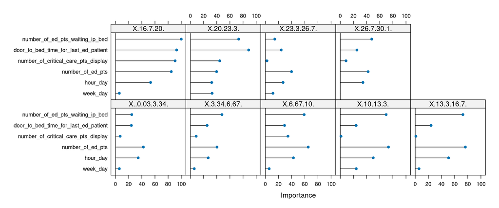

Variable Importance: Naive Bayes

```r
## Create a hyperparameter tuning grid
Grid <- data.frame(usekernel = FALSE, laplace = 0, adjust = 1)
## Run the Naive Bayes model
mdl <- train(wait_cat ~ .,data = final_data,
  method = "naive_bayes", trControl = trainControl(method = "none"),
  tuneGrid = Grid
)
## Plot the variable importance
plot(varImp(mdl))
```